# Análisis Estadístico con Aplicación en R

Entidad Financiera - 60 Clientes

16 de abril de 2026

# 1 Carga de Datos

```r
datos <- read.csv("../data/clientes_banco.csv", stringsAsFactors = FALSE)

# Recrear factores con etiquetas
datos$IndustriaCat <- factor(datos$Industria,
                             levels = c(0, 1, 2),
                             labels = c("Otra", "Manufactura", "Construcción"))

datos$OcupacionCat <- factor(datos$Ocupacion,
                             levels = c(0, 1, 2, 3, 4, 5),
                             labels = c("Otro", "Administrador", "Ventas",
                                        "Operario oficina", "Servicios generales",
                                        "Ingeniero"))
```

El dataset contiene **60 clientes** de una entidad financiera con 3 variables de estudio.

# 2 Punto 1: Descripción de la Población de Interés

La **población de interés** está conformada por los **60 clientes** de una entidad financiera (banco). Se busca caracterizar su comportamiento en función de tres variables fundamentales:

- **Salario Anual** (en dólares estadounidenses)
- **Tipo de Industria** en la que trabajan
- **Ocupación** laboral

El propósito del análisis es estudiar la base de datos para **ofrecer productos y servicios bancarios personalizados** para todos los clientes o segmentos específicos de ellos.

**Tamaño de la población:** N = 60 clientes.

# 3 Punto 2: Clasificación de las Variables

| Variable | Nombre | Tipo | Escala | Categorías |
| --- | --- | --- | --- | --- |
| X1 | Salario Anual (USD) | Cuantitativa continua | De razón | — |
| X2 | Tipo de Industria | Cualitativa nominal | Nominal | 0=Otra, 1=Manufactura, 2=Construcción |
| X3 | Ocupación | Cualitativa nominal | Nominal | 0=Otro, 1=Administrador, 2=Ventas, 3=Operario oficina, 4=Servicios generales, 5=Ingeniero |

- **X1 - Salario Anual:** Es una variable **cuantitativa continua** medida en escala de **razón**, ya que posee un cero absoluto (un salario de $0 tiene significado real), permite todas las operaciones aritméticas y sus valores pueden tomar cualquier número positivo dentro del rango observado.
- **X2 - Tipo de Industria:** Es una variable **cualitativa nominal** porque sus categorías (Otra, Manufactura, Construcción) no tienen un orden jerárquico natural.
- **X3 - Ocupación:** Es una variable **cualitativa nominal** puesto que las categorías de ocupación representan distintas funciones laborales sin un orden intrínseco.

# 4 Punto 3: Tabla de Frecuencias y Diagrama Circular - Ocupación

## 4.1 Tabla de Frecuencias

```r
freq_ocup <- table(datos$OcupacionCat)
rel_ocup <- prop.table(freq_ocup)

tabla_ocup <- data.frame(
  Categoría          = names(freq_ocup),
  `Frecuencia Absoluta` = as.integer(freq_ocup),
  `Frecuencia Relativa` = round(as.numeric(rel_ocup), 4),
  `Porcentaje (%)`      = round(as.numeric(rel_ocup) * 100, 2),
  `Frec. Acumulada`     = as.integer(cumsum(freq_ocup)),
  `Frec. Rel. Acum.`    = round(as.numeric(cumsum(rel_ocup)), 4),
  check.names = FALSE
)

knitr::kable(tabla_ocup, align = "lrrrrr",
             caption = "Tabla de frecuencias - Variable Ocupación")
```

Tabla de frecuencias - Variable Ocupación

| Categoría | Frecuencia Absoluta | Frecuencia Relativa | Porcentaje (%) | Frec. Acumulada | Frec. Rel. Acum. |
| --- | --- | --- | --- | --- | --- |
| Otro | 9 | 0.1500 | 15.00 | 9 | 0.1500 |
| Administrador | 10 | 0.1667 | 16.67 | 19 | 0.3167 |
| Ventas | 4 | 0.0667 | 6.67 | 23 | 0.3833 |
| Operario oficina | 12 | 0.2000 | 20.00 | 35 | 0.5833 |
| Servicios generales | 9 | 0.1500 | 15.00 | 44 | 0.7333 |
| Ingeniero | 16 | 0.2667 | 26.67 | 60 | 1.0000 |

## 4.2 Diagrama Circular

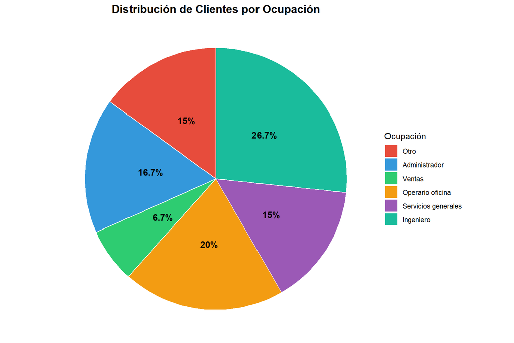

Diagrama circular de la variable Ocupación

```r
df_ocup <- as.data.frame(freq_ocup)
names(df_ocup) <- c("Ocupacion", "Frecuencia")
df_ocup$Porcentaje <- round(df_ocup$Frecuencia / sum(df_ocup$Frecuencia) * 100, 1)
df_ocup$Etiqueta <- paste0(df_ocup$Ocupacion, "\n", df_ocup$Frecuencia,
                            " (", df_ocup$Porcentaje, "%)")

colores <- c("#E74C3C", "#3498DB", "#2ECC71", "#F39C12", "#9B59B6", "#1ABC9C")

ggplot(df_ocup, aes(x = "", y = Frecuencia, fill = Ocupacion)) +
  geom_bar(stat = "identity", width = 1, color = "white") +
  coord_polar("y", start = 0) +
  scale_fill_manual(values = colores) +
  geom_text(aes(label = paste0(Porcentaje, "%")),
            position = position_stack(vjust = 0.5), size = 4, fontface = "bold") +
  labs(title = "Distribución de Clientes por Ocupación",
       fill = "Ocupación") +
  theme_void() +
  theme(plot.title = element_text(hjust = 0.5, size = 14, face = "bold"))
```

## 4.3 Interpretación

La ocupación con mayor representación en la cartera de clientes es **Ingeniero** con 16 clientes (26.7%), seguida de **Operario de oficina** con 12 clientes (20%). La categoría con menor frecuencia es **Ventas** con apenas 4 clientes (6.7%). Esta distribución sugiere que la entidad financiera atiende principalmente a profesionales técnicos y personal administrativo, lo cual es relevante para diseñar productos financieros orientados a estos perfiles laborales.

# 5 Punto 4: Tabla de Frecuencias y Diagrama de Barras - Industria

## 5.1 Tabla de Frecuencias

```r
freq_ind <- table(datos$IndustriaCat)
rel_ind <- prop.table(freq_ind)

tabla_ind <- data.frame(
  Categoría          = names(freq_ind),
  `Frecuencia Absoluta` = as.integer(freq_ind),
  `Frecuencia Relativa` = round(as.numeric(rel_ind), 4),
  `Porcentaje (%)`      = round(as.numeric(rel_ind) * 100, 2),
  `Frec. Acumulada`     = as.integer(cumsum(freq_ind)),
  `Frec. Rel. Acum.`    = round(as.numeric(cumsum(rel_ind)), 4),
  check.names = FALSE
)

knitr::kable(tabla_ind, align = "lrrrrr",
             caption = "Tabla de frecuencias - Variable Tipo de Industria")
```

Tabla de frecuencias - Variable Tipo de Industria

| Categoría | Frecuencia Absoluta | Frecuencia Relativa | Porcentaje (%) | Frec. Acumulada | Frec. Rel. Acum. |
| --- | --- | --- | --- | --- | --- |
| Otra | 22 | 0.3667 | 36.67 | 22 | 0.3667 |
| Manufactura | 23 | 0.3833 | 38.33 | 45 | 0.7500 |
| Construcción | 15 | 0.2500 | 25.00 | 60 | 1.0000 |

## 5.2 Diagrama de Barras

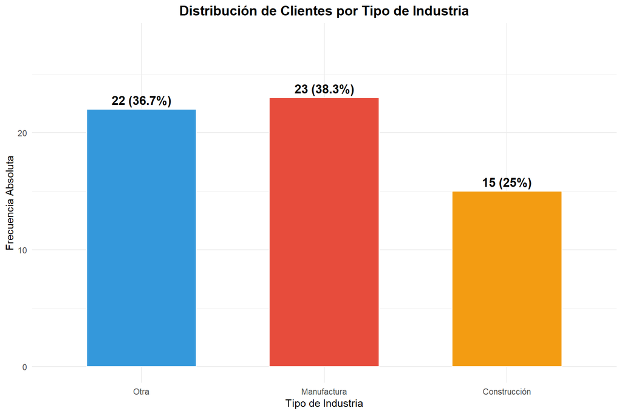

Diagrama de barras de la variable Tipo de Industria

```r
df_ind <- as.data.frame(freq_ind)
names(df_ind) <- c("Industria", "Frecuencia")
df_ind$Porcentaje <- round(df_ind$Frecuencia / sum(df_ind$Frecuencia) * 100, 1)

ggplot(df_ind, aes(x = Industria, y = Frecuencia, fill = Industria)) +
  geom_bar(stat = "identity", width = 0.6, color = "white", linewidth = 0.5) +
  geom_text(aes(label = paste0(Frecuencia, " (", Porcentaje, "%)")),
            vjust = -0.5, size = 4.5, fontface = "bold") +
  scale_fill_manual(values = c("#3498DB", "#E74C3C", "#F39C12")) +
  labs(title = "Distribución de Clientes por Tipo de Industria",
       x = "Tipo de Industria",
       y = "Frecuencia Absoluta") +
  ylim(0, max(df_ind$Frecuencia) + 5) +
  theme_minimal() +
  theme(plot.title = element_text(hjust = 0.5, size = 14, face = "bold"),
        legend.position = "none")
```

## 5.3 Interpretación

La distribución por tipo de industria muestra que **Manufactura** es el sector más representado con 23 clientes (38.3%), seguido muy de cerca por **Otra** con 22 clientes (36.7%). **Construcción** es el sector con menor presencia con 15 clientes (25%). La distribución es relativamente balanceada entre los tres sectores, lo que indica que la entidad financiera tiene una cartera diversificada en términos de la industria de sus clientes.

# 6 Punto 5: Tabla de Frecuencias e Histograma - Salario Anual

## 6.1 Tabla de Frecuencias

```r
n <- nrow(datos)
k <- ceiling(1 + 3.322 * log10(n))  # Regla de Sturges

rango <- max(datos$SalarioAnual) - min(datos$SalarioAnual)
amplitud <- ceiling(rango / k)
lim_inf <- min(datos$SalarioAnual)
cortes <- seq(lim_inf, lim_inf + k * amplitud, by = amplitud)
if (max(cortes) < max(datos$SalarioAnual)) {
  cortes <- c(cortes, max(cortes) + amplitud)
}

datos$ClaseSalario <- cut(datos$SalarioAnual, breaks = cortes, right = FALSE,
                          include.lowest = TRUE)

freq_sal <- table(datos$ClaseSalario)
rel_sal <- prop.table(freq_sal)

tabla_sal <- data.frame(
  Intervalo             = names(freq_sal),
  `Frecuencia Absoluta` = as.integer(freq_sal),
  `Frecuencia Relativa` = round(as.numeric(rel_sal), 4),
  `Porcentaje (%)`      = round(as.numeric(rel_sal) * 100, 2),
  `Frec. Acumulada`     = as.integer(cumsum(freq_sal)),
  `Frec. Rel. Acum.`    = round(as.numeric(cumsum(rel_sal)), 4),
  check.names = FALSE
)

knitr::kable(tabla_sal, align = "lrrrrr",
             caption = paste("Tabla de frecuencias - Salario Anual (k =", k, "clases, Regla de Sturges)"))
```

Tabla de frecuencias - Salario Anual (k = 7 clases, Regla de Sturges)

| Intervalo | Frecuencia Absoluta | Frecuencia Relativa | Porcentaje (%) | Frec. Acumulada | Frec. Rel. Acum. |
| --- | --- | --- | --- | --- | --- |
| [1.72e+04,2.84e+04) | 13 | 0.2167 | 21.67 | 13 | 0.2167 |
| [2.84e+04,3.95e+04) | 17 | 0.2833 | 28.33 | 30 | 0.5000 |
| [3.95e+04,5.06e+04) | 12 | 0.2000 | 20.00 | 42 | 0.7000 |
| [5.06e+04,6.17e+04) | 10 | 0.1667 | 16.67 | 52 | 0.8667 |
| [6.17e+04,7.28e+04) | 3 | 0.0500 | 5.00 | 55 | 0.9167 |
| [7.28e+04,8.39e+04) | 2 | 0.0333 | 3.33 | 57 | 0.9500 |
| [8.39e+04,9.5e+04] | 3 | 0.0500 | 5.00 | 60 | 1.0000 |

## 6.2 Histograma

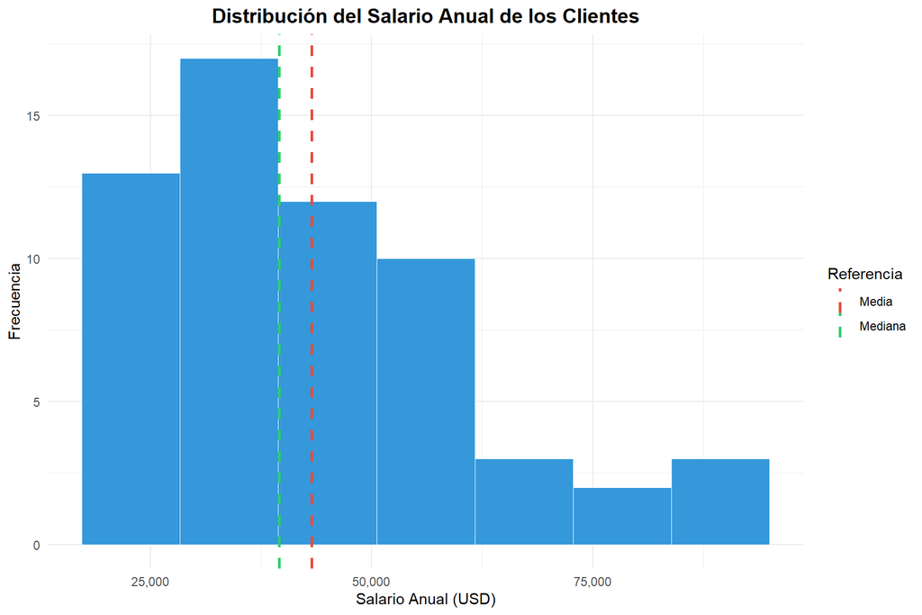

Histograma del Salario Anual

```r
media_sal <- mean(datos$SalarioAnual)
mediana_sal <- median(datos$SalarioAnual)

ggplot(datos, aes(x = SalarioAnual)) +
  geom_histogram(breaks = cortes, fill = "#3498DB", color = "white", linewidth = 0.3) +
  geom_vline(aes(xintercept = media_sal, color = "Media"),
             linetype = "dashed", linewidth = 1) +
  geom_vline(aes(xintercept = mediana_sal, color = "Mediana"),
             linetype = "dashed", linewidth = 1) +
  scale_color_manual(name = "Referencia",
                     values = c("Media" = "#E74C3C", "Mediana" = "#2ECC71")) +
  scale_x_continuous(labels = scales::comma) +
  labs(title = "Distribución del Salario Anual de los Clientes",
       x = "Salario Anual (USD)",
       y = "Frecuencia") +
  theme_minimal() +
  theme(plot.title = element_text(hjust = 0.5, size = 14, face = "bold"))
```

## 6.3 Interpretación

El histograma revela una distribución **asimétrica positiva** (sesgada a la derecha), lo que significa que la mayoría de los salarios se concentran en los rangos más bajos, con una cola que se extiende hacia los valores más altos. La mayor concentración de clientes se encuentra en el rango de salarios entre $28,000 y $39,000 USD. La media ($43,265) es mayor que la mediana ($39,580), confirmando la asimetría positiva. Esto indica la presencia de algunos clientes con salarios considerablemente más altos que el promedio.

# 7 Punto 6: Tabla Cruzada y Barras Apiladas - Ocupación x Industria

## 7.1 Tabla de Contingencia

```r
tabla_cruzada <- table(datos$OcupacionCat, datos$IndustriaCat)
tabla_con_margenes <- addmargins(tabla_cruzada)

knitr::kable(tabla_con_margenes,
             caption = "Tabla de contingencia: Ocupación x Tipo de Industria")
```

Tabla de contingencia: Ocupación x Tipo de Industria

|  | Otra | Manufactura | Construcción | Sum |
| --- | --- | --- | --- | --- |
| Otro | 1 | 4 | 4 | 9 |
| Administrador | 4 | 2 | 4 | 10 |
| Ventas | 2 | 2 | 0 | 4 |
| Operario oficina | 5 | 4 | 3 | 12 |
| Servicios generales | 3 | 4 | 2 | 9 |
| Ingeniero | 7 | 7 | 2 | 16 |
| Sum | 22 | 23 | 15 | 60 |

## 7.2 Diagrama de Barras Apiladas

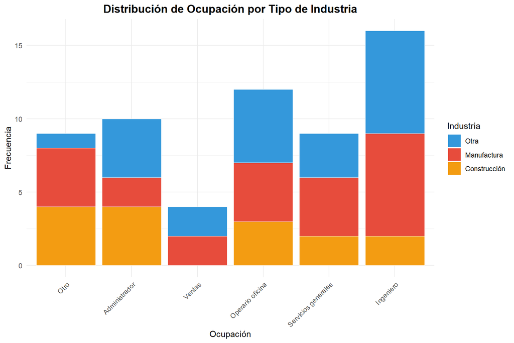

Diagrama de barras apiladas: Ocupación por Tipo de Industria

```r
df_cruzada <- as.data.frame(tabla_cruzada)
names(df_cruzada) <- c("Ocupacion", "Industria", "Frecuencia")

ggplot(df_cruzada, aes(x = Ocupacion, y = Frecuencia, fill = Industria)) +
  geom_bar(stat = "identity", color = "white", linewidth = 0.3) +
  scale_fill_manual(values = c("#3498DB", "#E74C3C", "#F39C12")) +
  labs(title = "Distribución de Ocupación por Tipo de Industria",
       x = "Ocupación",
       y = "Frecuencia",
       fill = "Industria") +
  theme_minimal() +
  theme(plot.title = element_text(hjust = 0.5, size = 14, face = "bold"),
        axis.text.x = element_text(angle = 45, hjust = 1))
```

## 7.3 Interpretación

La tabla cruzada y el diagrama de barras apiladas revelan la relación entre la ocupación y el tipo de industria de los clientes. Se observa que los **Ingenieros** constituyen el grupo más grande y se distribuyen principalmente entre las industrias “Otra” y “Manufactura”. Los **Operarios de oficina** también muestran una presencia significativa con distribución relativamente uniforme. La categoría **Ventas** tiene la menor representación y se concentra en los sectores Otra y Manufactura, sin presencia en Construcción. Esto permite a la entidad bancaria identificar nichos específicos para ofrecer productos diferenciados.

# 8 Punto 7: Resumen Estadístico - Salario Anual

```r
salario <- datos$SalarioAnual

# Medidas de centro
media <- mean(salario)
mediana <- median(salario)
calcular_moda <- function(x) {
  tb <- table(x)
  modas <- as.numeric(names(tb[tb == max(tb)]))
  if (length(modas) == length(unique(x))) return(NA)
  return(modas)
}
moda <- calcular_moda(salario)

# Medidas de posición
cuartiles <- quantile(salario, probs = c(0.25, 0.50, 0.75))
deciles <- quantile(salario, probs = seq(0.1, 0.9, by = 0.1))
percentiles <- quantile(salario, probs = c(0.10, 0.25, 0.50, 0.75, 0.90))

# Medidas de variación
rango_val <- max(salario) - min(salario)
iqr_val <- IQR(salario)
varianza <- var(salario)
desv_est <- sd(salario)
cv <- (desv_est / media) * 100

# Medidas de forma
asimetria <- skewness(salario)
curtosis_val <- kurtosis(salario)
```

## 8.1 Medidas de Tendencia Central

| Medida | Valor |
| --- | --- |
| Media aritmética | $43,264.83 USD |
| Mediana | $39,579.5 USD |
| Moda | $95,000 USD |

**Interpretación:** La media aritmética de $43,265 USD representa el salario promedio de todos los clientes. La mediana de $39,580 USD indica que el 50% de los clientes gana por debajo de este valor. La diferencia entre media y mediana (media > mediana) confirma la presencia de asimetría positiva, es decir, algunos salarios altos elevan el promedio.

## 8.2 Medidas de Posición

### 8.2.1 Cuartiles

| Cuartil | Percentil | Valor |
| --- | --- | --- |
| Q1 | 25% | $29,518 USD |
| Q2 | 50% | $39,579.5 USD |
| Q3 | 75% | $52,669.25 USD |

### 8.2.2 Deciles

```r
df_deciles <- data.frame(
  Decil = paste0("D", 1:9),
  Percentil = paste0(seq(10, 90, by = 10), "%"),
  Valor = paste0("$", format(round(deciles, 2), big.mark = ","), " USD")
)
knitr::kable(df_deciles, align = "llr", caption = "Deciles del Salario Anual")
```

Deciles del Salario Anual

| Decil | Percentil | Valor |
| --- | --- | --- |
| D1 | 10% | $21,424.3 USD |
| D2 | 20% | $27,939.2 USD |
| D3 | 30% | $31,694.0 USD |
| D4 | 40% | $35,120.2 USD |
| D5 | 50% | $39,579.5 USD |
| D6 | 60% | $45,904.6 USD |
| D7 | 70% | $50,594.3 USD |
| D8 | 80% | $54,297.8 USD |
| D9 | 90% | $67,372.0 USD |

**Interpretación:** Los cuartiles dividen la distribución en cuatro partes iguales. El rango intercuartílico (Q3 - Q1 = $23,151 USD) contiene el 50% central de los datos. El Q1 indica que el 25% de los clientes gana menos de $29,518 USD y el Q3 indica que el 75% gana menos de $52,669 USD.

## 8.3 Medidas de Variación (Dispersión)

| Medida | Valor |
| --- | --- |
| Valor mínimo | $17,250 USD |
| Valor máximo | $95,000 USD |
| Rango | $77,750 USD |
| Rango intercuartílico (IQR) | $23,151.25 USD |
| Varianza | 351,985,699 USD² |
| Desviación estándar | $18,761.28 USD |
| Coeficiente de variación (CV) | 43.36% |

**Interpretación:** La desviación estándar de $18,761 USD indica la dispersión promedio de los salarios respecto a la media. El coeficiente de variación del 43.4% es **alto (> 30%)**, lo que indica una distribución **heterogénea** en los salarios. Existe una variabilidad considerable entre los ingresos de los clientes.

## 8.4 Medidas de Forma

| Medida | Valor | Interpretación |
| --- | --- | --- |
| Asimetría (Skewness) | 0.9155 | Asimétrica positiva (sesgada a la derecha) |
| Curtosis (Kurtosis) | 3.5513 | Leptocúrtica (colas pesadas) |

**Interpretación:** El coeficiente de asimetría de 0.9155 confirma que la distribución es **asimétrica positiva**, es decir, la cola se extiende hacia la derecha con algunos clientes que tienen salarios significativamente superiores al promedio. La curtosis de 3.5513 indica una distribución **leptocúrtica**, lo que sugiere que los datos presentan colas más pesadas que una distribución normal, con mayor concentración de valores extremos.

# 9 Punto 8: Diagramas de Caja y Bigotes - Ocupación vs Salario Anual

## 9.1 Resumen por Ocupación

```r
resumen <- aggregate(SalarioAnual ~ OcupacionCat, data = datos, FUN = function(x) {
  c(n = length(x),
    Media = round(mean(x), 0),
    Mediana = round(median(x), 0),
    Min = min(x),
    Max = max(x),
    Desv.Est = round(sd(x), 0))
})
resumen_df <- do.call(data.frame, resumen)
names(resumen_df) <- c("Ocupación", "n", "Media", "Mediana", "Mín", "Máx", "Desv.Est")
knitr::kable(resumen_df, align = "lrrrrrr",
             caption = "Resumen estadístico del Salario Anual por Ocupación")
```

Resumen estadístico del Salario Anual por Ocupación

| Ocupación | n | Media | Mediana | Mín | Máx | Desv.Est |
| --- | --- | --- | --- | --- | --- | --- |
| Otro | 9 | 46654 | 45435 | 19388 | 86188 | 18914 |
| Administrador | 10 | 42811 | 43093 | 21454 | 67390 | 13650 |
| Ventas | 4 | 57412 | 49290 | 36070 | 95000 | 25963 |
| Operario oficina | 12 | 36044 | 31989 | 19507 | 61397 | 13599 |
| Servicios generales | 9 | 44851 | 45857 | 19096 | 95000 | 25396 |
| Ingeniero | 16 | 42628 | 39448 | 17250 | 83601 | 19064 |

## 9.2 Diagrama de Caja y Bigotes

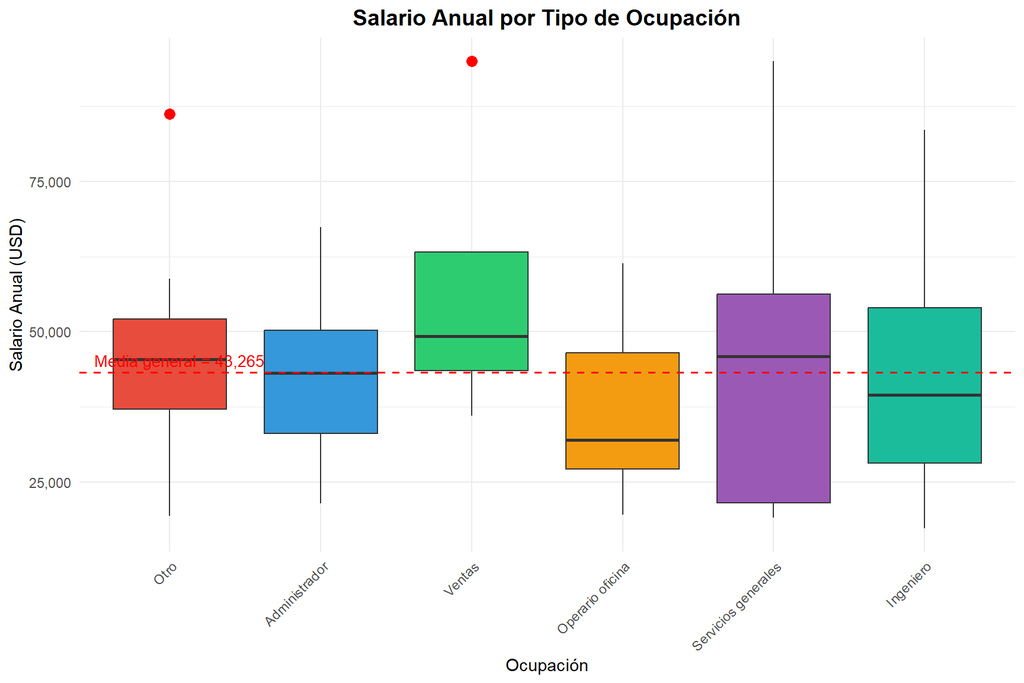

Diagramas de caja y bigotes: Salario Anual por Ocupación

```r
ggplot(datos, aes(x = OcupacionCat, y = SalarioAnual, fill = OcupacionCat)) +
  geom_boxplot(outlier.color = "red", outlier.shape = 16, outlier.size = 3) +
  geom_hline(yintercept = mean(datos$SalarioAnual),
             linetype = "dashed", color = "red", linewidth = 0.7) +
  annotate("text", x = 0.5, y = mean(datos$SalarioAnual) + 2000,
           label = paste("Media general =", format(round(mean(datos$SalarioAnual), 0), big.mark = ",")),
           hjust = 0, color = "red", size = 3.5) +
  scale_fill_manual(values = c("#E74C3C", "#3498DB", "#2ECC71", "#F39C12", "#9B59B6", "#1ABC9C")) +
  scale_y_continuous(labels = scales::comma) +
  labs(title = "Salario Anual por Tipo de Ocupación",
       x = "Ocupación",
       y = "Salario Anual (USD)") +
  theme_minimal() +
  theme(plot.title = element_text(hjust = 0.5, size = 14, face = "bold"),
        axis.text.x = element_text(angle = 45, hjust = 1),
        legend.position = "none")
```

## 9.3 Interpretación

Estos hallazgos son valiosos para que la entidad financiera diseñe productos diferenciados según el perfil salarial de cada ocupación.

*Análisis realizado con R versión R version 4.5.3 (2026-03-11 ucrt)*